# Research Methodology - Quantitative

# 8. Probability Primer

Source: Principles of Econometrics 4th ed by R.Carter Hill

## Random Variable

A random variable is a variable whose value is unknown until it is observed—in other words, a variable that is not perfectly predictable. Each random variable has a set of possible values it can take.

For example, if W represents the number of games our football team wins next year, then W can take the values 0, 1, 2, …, up to 13, assuming there are at most 13 games. This is a discrete random variable because it can only take a limited or countable number of values.

A special case of a discrete random variable occurs when it can take only two possible values. For instance, in a phone survey, if you are asked whether you are a college graduate, your answer can only be “yes” or “no.” Outcomes like this can be represented using an indicator variable, which takes the value 1 if the answer is “yes,” and 0 if the answer is “no.” Indicator variables are discrete and are commonly used to represent qualitative characteristics, such as gender (male or female) or race (white or nonwhite).

On the other hand, GDP (Gross Domestic Product) can, for practical purposes, take any value in the interval from zero to infinity. It is therefore treated as a continuous random variable. Other common macroeconomic variables, such as interest rates, investment, and consumption, are also modeled as continuous random variables. In finance, stock market indices like the Dow Jones Industrial Index are treated the same way. The defining feature of these variables is that they can take any value within a given interval, which makes them continuous.

## Probability Distributions

Probability is usually defined in terms of experiments.

### Probability Density Function (PDF)

We summarize the probabilities of possible outcomes using a **probability density function** (pdf).  
The pdf for a discrete random variable indicates the probability of each possible value occurring.

Let **X** be a discrete random variable. Then the value of the probability density function **f(x)** is defined as:

$$f(x) = P(X = x)$$

Because **f(x)** is a probability, the following conditions must hold:

- $0 \leq f(x) \leq 1$
- If **X** takes **n** possible values $x_1, x_2, \ldots, x_n$, then their total probability must sum to 1:

$$f(x_1) + f(x_2) + \cdots + f(x_n) = 1$$

### Cumulative Distribution Function (CDF)

An alternative way to represent probabilities is through the **cumulative distribution function** (cdf).

The cdf of the random variable **X**, denoted **F(x)**, gives the probability that **X** is less than or equal to a specific value **x**:

$$F(x) = P(X \leq x)$$

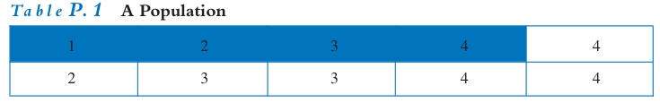

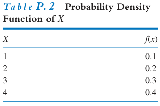

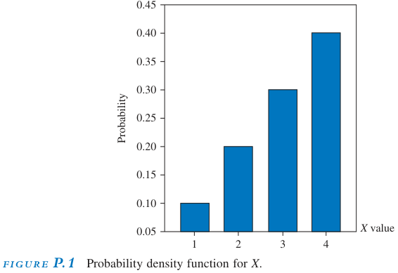

# 9a. Regression Exercise Part 1

```r
# 1. Persiapan Awal
knitr::opts_chunk$set(echo = TRUE)

# 2. Mengimpor Data dari GitHub
url <- "https://raw.githubusercontent.com/davidsyambudi/Latihan-Kuantitatif/6301b4aba6f6d62e0dea96ae6e0ecaa3089a3b79/9a_data_investasi_suku_bunga.csv"
data <- read.csv(url)

# 3. Tampilkan sebagian data untuk verifikasi
head(data)
```

```
##   Tingkat_Suku_Bunga Investasi
## 1               5.75    793.50
## 2              11.51    666.31
## 3               9.32    735.05
## 4               7.99    724.58
## 5               3.56    986.49
## 6               3.56    916.89
```

```r
# 4. Struktur dan Ringkasan Data
str(data)
```

```
## 'data.frame':    200 obs. of  2 variables:
##  $ Tingkat_Suku_Bunga: num  5.75 11.51 9.32 7.99 3.56 ...
##  $ Investasi         : num  794 666 735 725 986 ...
```

```r
summary(data)
```

```
##  Tingkat_Suku_Bunga   Investasi
##  Min.   : 2.060     Min.   : 550.5
##  1st Qu.: 4.287     1st Qu.: 714.9
##  Median : 6.945     Median : 794.7
##  Mean   : 6.840     Mean   : 798.2
##  3rd Qu.: 9.572     3rd Qu.: 872.3
##  Max.   :11.870     Max.   :1073.8
```

```r
# 5. Estimasi Model Regresi Linier
model <- lm(Investasi ~ Tingkat_Suku_Bunga, data = data)
summary(model)
```

```
##
## Call:
## lm(formula = Investasi ~ Tingkat_Suku_Bunga, data = data)
##
## Residuals:
##      Min       1Q   Median       3Q      Max
## -166.187  -36.450    1.066   29.355  188.146
##
## Coefficients:
##                    Estimate Std. Error t value Pr(>|t|)
## (Intercept)        1006.039      8.692  115.74   <2e-16 ***
## Tingkat_Suku_Bunga  -30.390      1.167  -26.03   <2e-16 ***
## ---
## Signif. codes:  0 '***' 0.001 '**' 0.01 '*' 0.05 '.' 0.1 ' ' 1
##
## Residual standard error: 48.56 on 198 degrees of freedom
## Multiple R-squared:  0.7739, Adjusted R-squared:  0.7728
## F-statistic: 677.7 on 1 and 198 DF,  p-value: < 2.2e-16
```

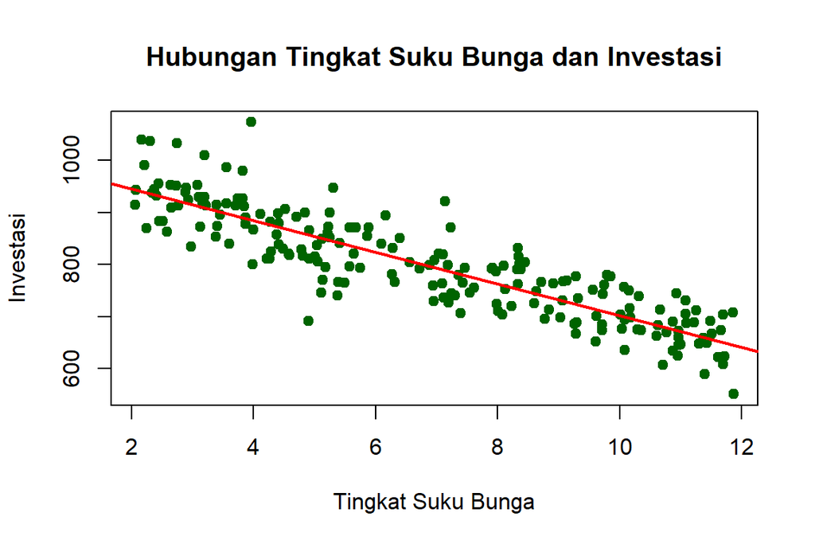

```r
# 6. Visualisasi: Scatter Plot dan Garis Regresi
plot(data$Tingkat_Suku_Bunga, data$Investasi,
     main = "Hubungan Tingkat Suku Bunga dan Investasi",
     xlab = "Tingkat Suku Bunga",
     ylab = "Investasi",
     pch = 19,
     col = "darkgreen")
abline(model, col = "red", lwd = 2)
```

# 9b. Regression Exercise Part 2

```r
# 1. Persiapan awal
knitr::opts_chunk$set(echo = TRUE, warning = FALSE, message = FALSE)
library(readr)
library(dplyr)

# 2. Pengambilan dan pembersihan data
url <- "https://raw.githubusercontent.com/davidsyambudi/Latihan-Kuantitatif/6301b4aba6f6d62e0dea96ae6e0ecaa3089a3b79/9b_data_perbankan_syariah.csv"
raw <- read_lines(url)
csv_text <- paste(raw, collapse = "\n")

data <- read_delim(
  file = csv_text,
  delim = ";",
  locale = locale(decimal_mark = ","),
  col_types = cols(
    Periode = col_character(),
    ROA = col_double(),
    NPL = col_double(),
    SWBI = col_double(),
    IPI = col_double(),
    LDR = col_double()
  )
)

data <- na.omit(data)
glimpse(data)
```

```
## Rows: 36
## Columns: 6
## $ Periode <chr> "2003.1", "2003.2", "2003.3", "2003.4", "2003.5", "2003.6", "2…
## $ ROA     <dbl> 0.32, 0.39, 0.43, 0.56, 0.61, 0.65, 0.74, 0.81, 0.83, 0.66, 0.…
## $ NPL     <dbl> 4.06, 4.00, 3.96, 3.91, 3.98, 3.93, 3.96, 3.96, 3.96, 3.67, 3.…
## $ SWBI    <dbl> 7.52, 6.49, 10.32, 9.51, 5.50, 7.98, 9.11, 7.11, 9.31, 8.75, 8…
## $ IPI     <dbl> 107.27, 105.82, 114.52, 107.80, 110.66, 116.36, 118.59, 119.59…
## $ LDR     <dbl> 102.20, 100.00, 99.11, 99.50, 100.50, 100.82, 96.04, 92.91, 90…
```

```r
# 3. Estimasi model regresi
model <- lm(LDR ~ ROA + NPL + SWBI + IPI, data = data)
summary(model)
```

```
##
## Call:
## lm(formula = LDR ~ ROA + NPL + SWBI + IPI, data = data)
##
## Residuals:
##      Min       1Q   Median       3Q      Max
## -10.9035  -2.7911   0.6308   2.9422   8.0330
##
## Coefficients:
##              Estimate Std. Error t value Pr(>|t|)
## (Intercept) 72.090727  12.002845   6.006 1.21e-06 ***
## ROA          9.557832   3.430293   2.786 0.009017 **
## NPL          6.084018   1.604390   3.792 0.000649 ***
## SWBI        -0.424538   0.481127  -0.882 0.384361
## IPI         -0.001278   0.114841  -0.011 0.991192
## ---
## Signif. codes:  0 '***' 0.001 '**' 0.01 '*' 0.05 '.' 0.1 ' ' 1
##
## Residual standard error: 5.048 on 31 degrees of freedom
## Multiple R-squared:  0.5465, Adjusted R-squared:  0.488
## F-statistic: 9.339 on 4 and 31 DF,  p-value: 4.502e-05
```

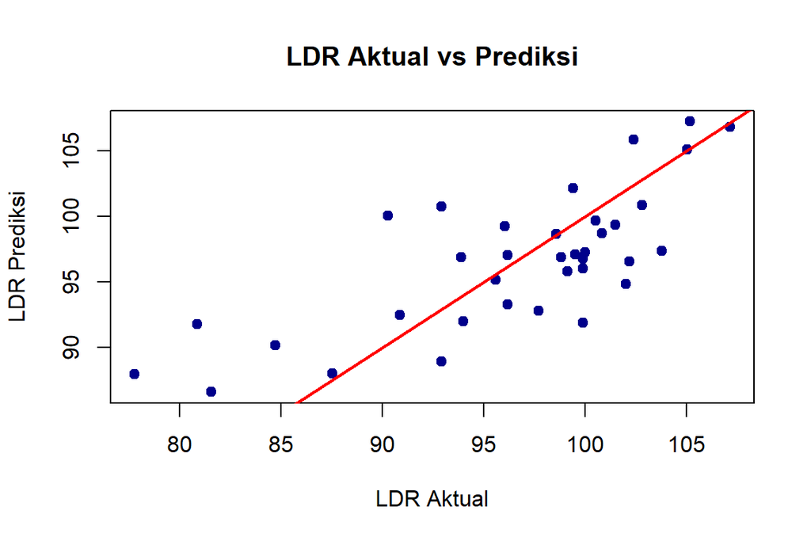

```r
# 4. Prediksi dan visualisasi
data <- data %>% mutate(Prediksi = predict(model))

plot(data$LDR, data$Prediksi,
     main = "LDR Aktual vs Prediksi",
     xlab = "LDR Aktual",
     ylab = "LDR Prediksi",
     col = "darkblue", pch = 19)
abline(a = 0, b = 1, col = "red", lwd = 2)
```

# 10. Using “PoEdata” and OLS in R

## 1. Introduction

In this tenth session, we will explore how to access and use econometrics datasets for hands-on practice using R. The datasets used in this session are sourced from the *Principles of Econometrics, 4th Edition* by Hill, Griffiths, and Lim. They are available in the following formats:

- **Stata (.dta)**: http://www.principlesofeconometrics.com/poe4/poe4stata.htm
- **Excel Spreadsheet**: http://www.principlesofeconometrics.com/poe4/poe4excel.htm
- **R Dataset Package**: https://github.com/ccolonescu/PoEdata

Although the original format is intended for Stata, this course will use R for all analytical work.

## 2. Installing the `PoEdata` Package

The `PoEdata` package contains a collection of datasets for econometric practice. It was developed by **Constantin Colonescu** and made available on GitHub.

### 2.1 Step-by-Step Installation

```r
## Install devtools if not already installed
install.packages("devtools")

## Load devtools
library(devtools)

## Install PoEdata from GitHub
install_git("https://github.com/ccolonescu/PoEdata")
```

### 2.2 Common Installation Issues and Solutions

#### 2.2.1 Rtools Not Installed

**Error Message:**

```
WARNING: Rtools is required to build R packages, but is not currently installed.
```

**Solution:**

- Download and install Rtools 4.5: https://cran.r-project.org/bin/windows/Rtools/
- During installation, check the option to **add Rtools to system PATH**.
- Verify installation:

```r
pkgbuild::has_build_tools(debug = TRUE)
```

#### 2.2.2 Git Not Installed

**Error Message:**

```
Error: Failed to install 'unknown package' from Git:
  Git does not seem to be installed on your system.
```

**Solution:**

- Download Git for Windows: https://git-scm.com/download/win
- Choose **“Git from the command line and also from 3rd-party software”** during installation.
- Restart RStudio and verify:

```r
system("git --version")
```

Expected output:

```
git version 2.43.0.windows.1
```

#### 2.2.3 Alternative Installation via `remotes` (Recommended)

```r
install.packages("remotes")  ## if not already installed
remotes::install_github("ccolonescu/PoEdata")
```

### 2.3 Troubleshooting PATH Issues

If R returns `[1] 127` after Git installation, it means Git is not found in system PATH. Fix by:

1. Locate Git path (e.g., `C:\\Program Files\\Git\\cmd`)
2. Open: **Control Panel → System → Advanced System Settings → Environment Variables**
3. Edit the `Path` variable and add Git directory
4. Restart RStudio

Then test again:

```r
system("git --version")
```

## 3. Summary of Installation

By following the steps above, you will be able to:

- Install essential tools (`Git`, `Rtools`, `PoEdata`)
- Resolve common installation errors
- Prepare your R environment for hands-on econometric analysis

```r
library(PoEdata)
```

## 4. Food Expenditure Data

### 4.1 Load and Examine the Data

```r
data(food)
str(food)
```

```
## 'data.frame':    40 obs. of  2 variables:
##  $ food_exp: num  115 136 119 115 187 ...
##  $ income  : num  3.69 4.39 4.75 6.03 12.47 ...
##  - attr(*, "datalabel")= chr ""
##  - attr(*, "time.stamp")= chr ""
##  - attr(*, "formats")= chr [1:2] "%10.0g" "%10.0g"
##  - attr(*, "types")= int [1:2] 255 255
##  - attr(*, "val.labels")= chr [1:2] "" ""
##  - attr(*, "var.labels")= chr [1:2] "household food expenditure per week" "weekly household income"
##  - attr(*, "version")= int 12
```

```r
head(food, 5)
```

```
##   food_exp income
## 1   115.22   3.69
## 2   135.98   4.39
## 3   119.34   4.75
## 4   114.96   6.03
## 5   187.05  12.47
```

```r
food[1:5, "food_exp"]
```

```
## [1] 115.22 135.98 119.34 114.96 187.05
```

```r
subset(food, income < 10)
```

```
##   food_exp income
## 1   115.22   3.69
## 2   135.98   4.39
## 3   119.34   4.75
## 4   114.96   6.03
```

### 4.2 Summary Statistics

```r
summary(food)
```

```
##     food_exp         income
##  Min.   :109.7   Min.   : 3.69
##  1st Qu.:200.4   1st Qu.:17.11
##  Median :264.5   Median :20.03
##  Mean   :283.6   Mean   :19.60
##  3rd Qu.:363.3   3rd Qu.:24.40
##  Max.   :587.7   Max.   :33.40
```

```r
summary(food$food_exp)
```

```
##    Min. 1st Qu.  Median    Mean 3rd Qu.    Max.
##   109.7   200.4   264.5   283.6   363.3   587.7
```

### 4.3 Scatter Plot: Food Expenditure vs Income

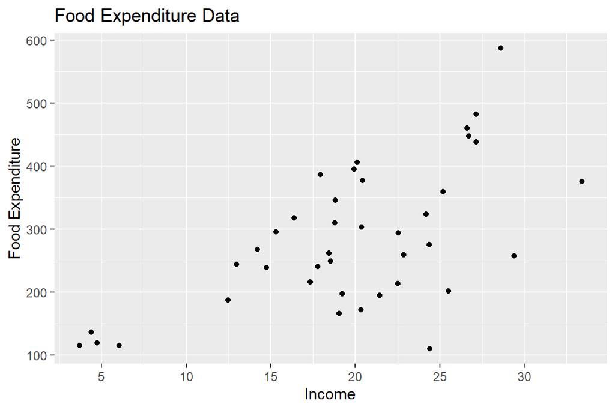

```r
library(ggplot2)

ggplot(food, aes(x = income, y = food_exp)) +
  geom_point() +
  labs(title = "Food Expenditure Data",
       x = "Income", y = "Food Expenditure") +
  scale_y_continuous(breaks = seq(0, 600, 100)) +
  scale_x_continuous(breaks = seq(0, 35, 5))
```

### 4.4 Linear Regression and Elasticity

```r
model1 <- lm(food_exp ~ income, data = food)
summary(model1)
```

```
##
## Call:
## lm(formula = food_exp ~ income, data = food)
##
## Residuals:
##      Min       1Q   Median       3Q      Max
## -223.025  -50.816   -6.324   67.879  212.044
##
## Coefficients:
##             Estimate Std. Error t value Pr(>|t|)
## (Intercept)   83.416     43.410   1.922   0.0622 .
## income        10.210      2.093   4.877 1.95e-05 ***
## ---
## Signif. codes:  0 '***' 0.001 '**' 0.01 '*' 0.05 '.' 0.1 ' ' 1
##
## Residual standard error: 89.52 on 38 degrees of freedom
## Multiple R-squared:  0.385,  Adjusted R-squared:  0.3688
## F-statistic: 23.79 on 1 and 38 DF,  p-value: 1.946e-05
```

```r
food$yhat <- predict(model1)
food$ehat <- residuals(model1)

mean_income <- mean(food$income)
mean_yhat <- mean(food$yhat)
elas_mean <- coef(model1)["income"] * mean_income / mean_yhat

food$elas <- coef(model1)["income"] * food$income / food$yhat
summary(food$elas)
```

```
##    Min. 1st Qu.  Median    Mean 3rd Qu.    Max.
##  0.3111  0.6767  0.7103  0.6796  0.7491  0.8035
```

### 4.5 Plot with Fitted Line

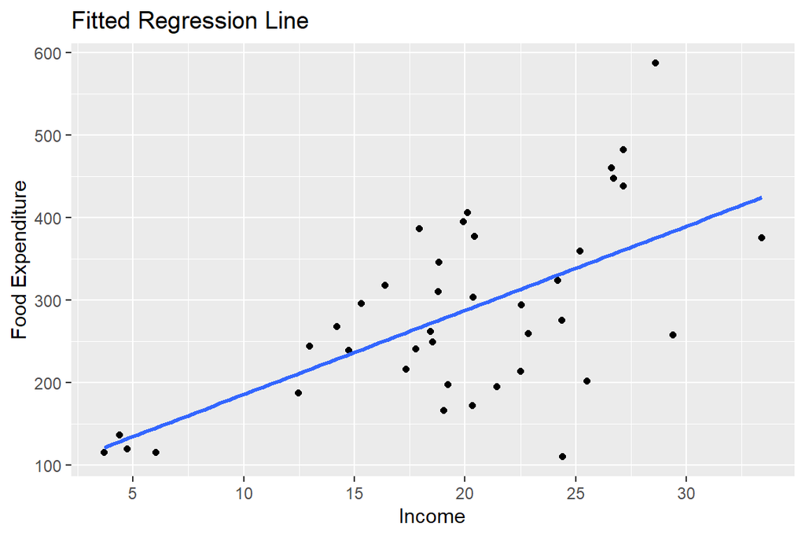

```r
ggplot(food, aes(x = income, y = food_exp)) +
  geom_point() +
  geom_smooth(method = "lm", se = FALSE) +
  labs(title = "Fitted Regression Line",
       x = "Income", y = "Food Expenditure") +
  scale_y_continuous(breaks = seq(0, 600, 100)) +
  scale_x_continuous(breaks = seq(0, 35, 5))
```

## 5. Quadratic Model Example

### 5.1 Load and Estimate Model

```r
data(br)
summary(br)
```

```
##      price              sqft         bedrooms        baths
##  Min.   :  22000   Min.   : 662   Min.   :1.00   Min.   :1.000
##  1st Qu.:  99000   1st Qu.:1604   1st Qu.:3.00   1st Qu.:2.000
##  Median : 130000   Median :2186   Median :3.00   Median :2.000
##  Mean   : 154863   Mean   :2326   Mean   :3.18   Mean   :1.973
##  3rd Qu.: 170163   3rd Qu.:2800   3rd Qu.:4.00   3rd Qu.:2.000
##  Max.   :1580000   Max.   :7897   Max.   :8.00   Max.   :5.000
##       age          occupancy          pool             style
##  Min.   : 1.00   Min.   :1.000   Min.   :0.00000   Min.   : 1.000
##  1st Qu.: 5.00   1st Qu.:1.000   1st Qu.:0.00000   1st Qu.: 1.000
##  Median :18.00   Median :2.000   Median :0.00000   Median : 1.000
##  Mean   :19.57   Mean   :1.565   Mean   :0.07963   Mean   : 3.753
##  3rd Qu.:25.00   3rd Qu.:2.000   3rd Qu.:0.00000   3rd Qu.: 7.000
##  Max.   :80.00   Max.   :3.000   Max.   :1.00000   Max.   :11.000
##    fireplace       waterfront           dom
##  Min.   :0.000   Min.   :0.00000   Min.   :  0.00
##  1st Qu.:0.000   1st Qu.:0.00000   1st Qu.: 14.00
##  Median :1.000   Median :0.00000   Median : 40.00
##  Mean   :0.563   Mean   :0.07222   Mean   : 74.06
##  3rd Qu.:1.000   3rd Qu.:0.00000   3rd Qu.:100.25
##  Max.   :1.000   Max.   :1.00000   Max.   :728.00
```

```r
br$sqft2 <- br$sqft^2
model2 <- lm(price ~ sqft2, data = br)
br$priceq <- predict(model2)
```

### 5.2 Plot Quadratic Fit

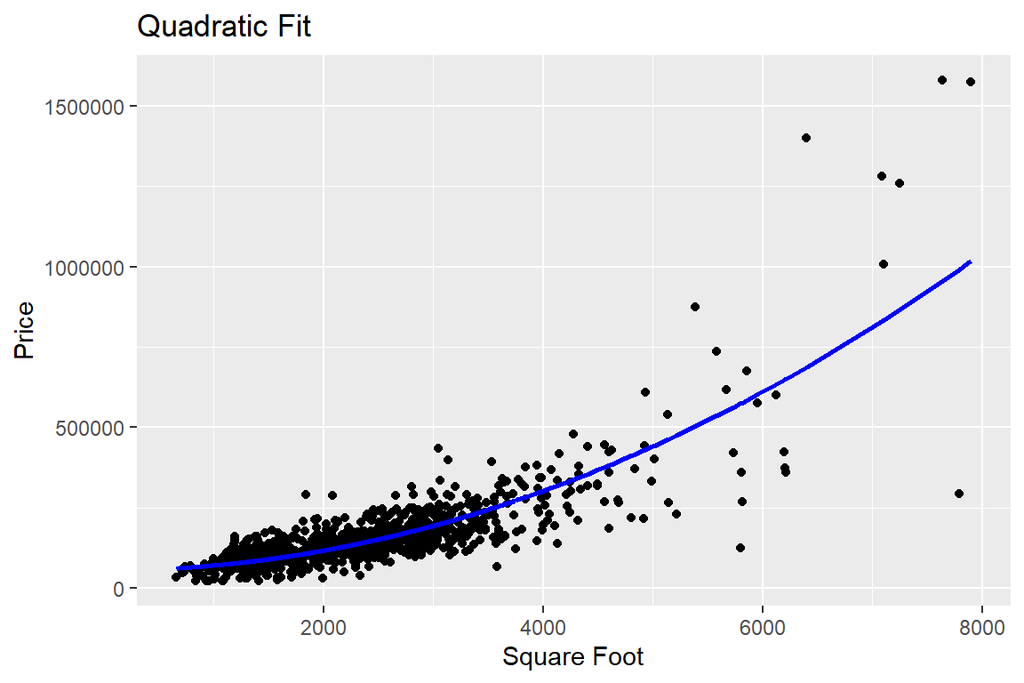

```r
ggplot(br, aes(x = sqft, y = price)) +
  geom_point() +
  geom_line(aes(y = priceq), color = "blue", linewidth = 1) +
  labs(title = "Quadratic Fit", x = "Square Foot", y = "Price")
```

### 5.3 Slope and Elasticity at a Point

```r
b2 <- coef(model2)["sqft2"]
intercept <- coef(model2)["(Intercept)"]

slope_2000 <- 2 * b2 * 2000
pred_2000 <- intercept + b2 * 2000^2
elas_2000 <- slope_2000 * 2000 / pred_2000
```

## 6. Log-linear Model

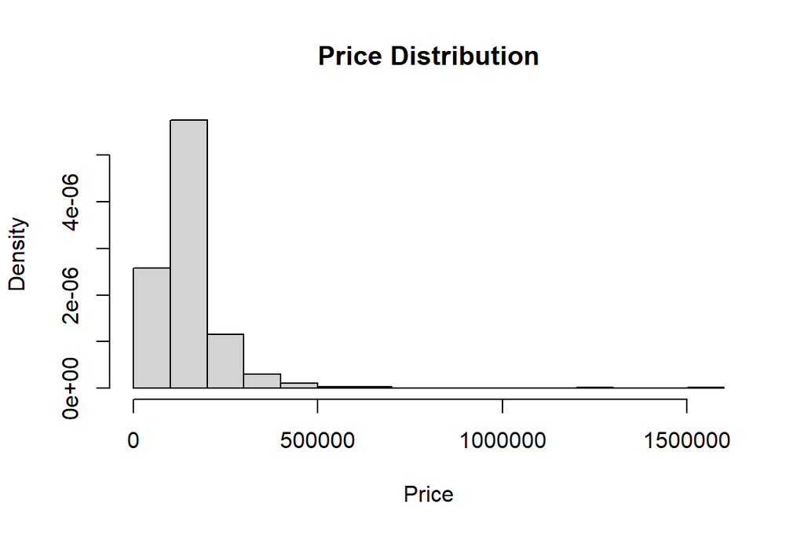

```r
br$lprice <- log(br$price)

hist(br$price, breaks = 20, main = "Price Distribution", xlab = "Price", freq = FALSE)
```

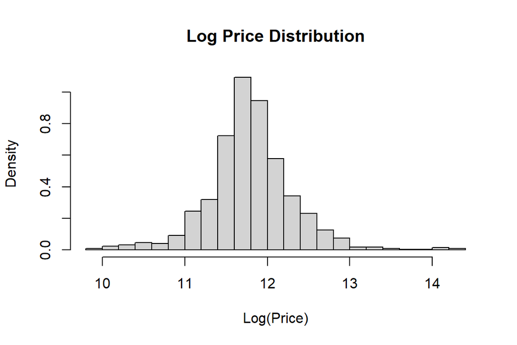

```r
hist(br$lprice, breaks = 20, main = "Log Price Distribution", xlab = "Log(Price)", freq = FALSE)
```

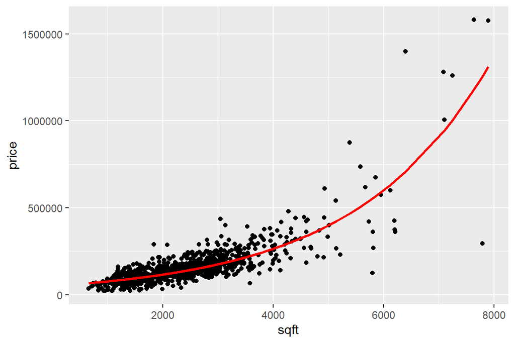

```r
model3 <- lm(lprice ~ sqft, data = br)
br$lpricef <- predict(model3)
br$pricef <- exp(br$lpricef)

ggplot(br, aes(x = sqft, y = price)) +
  geom_point() +
  geom_line(aes(y = pricef), color = "red", linewidth = 1)
```

### 6.1 Elasticity and Marginal Effects

```r
b_sqft <- coef(model3)["sqft"]
br$me <- b_sqft * br$pricef
br$elas <- b_sqft * br$sqft

summary(br$me)
```

```
##    Min. 1st Qu.  Median    Mean 3rd Qu.    Max.
##   27.51   40.54   51.50   61.00   66.28  539.22
```

```r
summary(br$elas)
```

```
##    Min. 1st Qu.  Median    Mean 3rd Qu.    Max.
##  0.2723  0.6599  0.8992  0.9566  1.1516  3.2478
```

## 7. Indicator Variable Model (University Town)

```r
data(utown)
summary(utown)
```

```
##      price            sqft            age             utown
##  Min.   :134.3   Min.   :20.03   Min.   : 0.000   Min.   :0.000
##  1st Qu.:215.6   1st Qu.:22.83   1st Qu.: 3.000   1st Qu.:0.000
##  Median :245.8   Median :25.36   Median : 6.000   Median :1.000
##  Mean   :247.7   Mean   :25.21   Mean   : 9.392   Mean   :0.519
##  3rd Qu.:278.3   3rd Qu.:27.75   3rd Qu.:13.000   3rd Qu.:1.000
##  Max.   :345.2   Max.   :30.00   Max.   :60.000   Max.   :1.000
##       pool           fplace
##  Min.   :0.000   Min.   :0.000
##  1st Qu.:0.000   1st Qu.:0.000
##  Median :0.000   Median :1.000
##  Mean   :0.204   Mean   :0.518
##  3rd Qu.:0.000   3rd Qu.:1.000
##  Max.   :1.000   Max.   :1.000
```

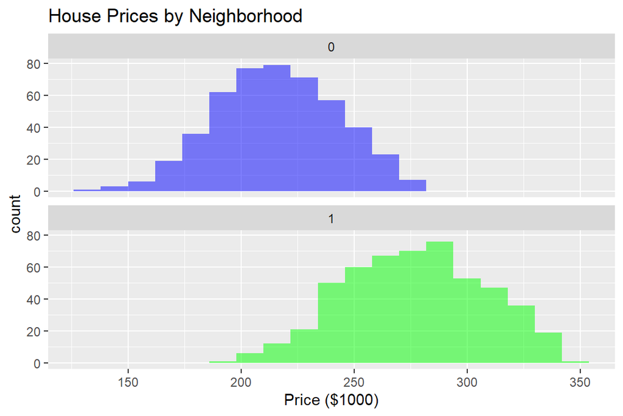

```r
ggplot(utown, aes(x = price)) +
  geom_histogram(data = subset(utown, utown == 0), binwidth = 12, fill = "blue", alpha = 0.5) +
  geom_histogram(data = subset(utown, utown == 1), binwidth = 12, fill = "green", alpha = 0.5) +
  facet_wrap(~ utown, ncol = 1) +
  labs(title = "House Prices by Neighborhood", x = "Price ($1000)")
```

```r
model4 <- lm(price ~ factor(utown), data = utown)
summary(model4)
```

```
##
## Call:
## lm(formula = price ~ factor(utown), data = utown)
##
## Residuals:
##     Min      1Q  Median      3Q     Max
## -85.672 -20.359  -0.462  20.646  67.955
##
## Coefficients:
##                Estimate Std. Error t value Pr(>|t|)
## (Intercept)     215.732      1.318  163.67   <2e-16 ***
## factor(utown)1   61.509      1.830   33.62   <2e-16 ***
## ---
## Signif. codes:  0 '***' 0.001 '**' 0.01 '*' 0.05 '.' 0.1 ' ' 1
##
## Residual standard error: 28.91 on 998 degrees of freedom
## Multiple R-squared:  0.5311, Adjusted R-squared:  0.5306
## F-statistic:  1130 on 1 and 998 DF,  p-value: < 2.2e-16
```

```r
t.test(price ~ utown, data = utown)
```

```
##
##  Welch Two Sample t-test
##
## data:  price by utown
## t = -33.799, df = 993.87, p-value < 2.2e-16
## alternative hypothesis: true difference in means between group 0 and group 1 is not equal to 0
## 95 percent confidence interval:
##  -65.08035 -57.93787
## sample estimates:
## mean in group 0 mean in group 1
##        215.7325        277.2416
```

## 8. Simulated Data Experiment

### 8.1 Generate and Model Simulated Data

```r
set.seed(1234567)
n <- 40
beta1 <- 100
beta2 <- 10
sigma <- 50

x <- rep(c(10, 20), each = n/2)
e <- rnorm(n, mean = 0, sd = sigma)
y <- beta1 + beta2 * x + e

sim_data <- data.frame(x, y)
model_sim <- lm(y ~ x, data = sim_data)
summary(model_sim)
```

```
##
## Call:
## lm(formula = y ~ x, data = sim_data)
##
## Residuals:
##     Min      1Q  Median      3Q     Max
## -88.215 -23.826  -1.099  30.131  78.061
##
## Coefficients:
##             Estimate Std. Error t value Pr(>|t|)
## (Intercept)  113.948     20.551   5.545 2.40e-06 ***
## x              8.507      1.300   6.545 1.02e-07 ***
## ---
## Signif. codes:  0 '***' 0.001 '**' 0.01 '*' 0.05 '.' 0.1 ' ' 1
##
## Residual standard error: 41.1 on 38 degrees of freedom
## Multiple R-squared:  0.5299, Adjusted R-squared:  0.5176
## F-statistic: 42.84 on 1 and 38 DF,  p-value: 1.021e-07
```

### 8.2 Monte Carlo Simulation

```r
simulate_model <- function() {
  x <- rep(c(10, 20), each = n/2)
  e <- rnorm(n, mean = 0, sd = sigma)
  y <- beta1 + beta2 * x + e
  model <- lm(y ~ x)
  return(c(b1 = coef(model)[1], b2 = coef(model)[2], sig2 = sigma^2))
}

sim_results <- replicate(1000, simulate_model())
sim_df <- as.data.frame(t(sim_results))

summary(sim_df)
```

```
##  b1.(Intercept)        b2.x             sig2
##  Min.   : 19.85   Min.   : 4.899   Min.   :2500
##  1st Qu.: 83.59   1st Qu.: 8.854   1st Qu.:2500
##  Median :101.10   Median : 9.917   Median :2500
##  Mean   :100.97   Mean   : 9.926   Mean   :2500
##  3rd Qu.:118.20   3rd Qu.:10.937   3rd Qu.:2500
##  Max.   :182.94   Max.   :15.052   Max.   :2500
```

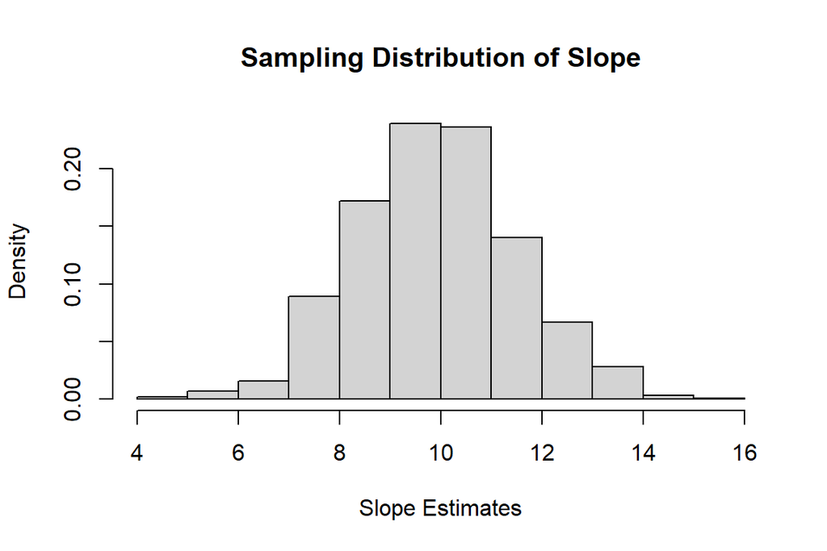

```r
hist(sim_df$b2, freq = FALSE, main = "Sampling Distribution of Slope", xlab = "Slope Estimates")
```

# 11. Time Series

## 1. Import Data

```r
library(readr)
library(dplyr)

url <- "https://raw.githubusercontent.com/davidsyambudi/Latihan-Kuantitatif/93ebaba678dd4e2559c6cad12e8596b1493fab8d/data_dummy_ekonomi.csv"
data <- read_csv(url)

# Pastikan format tanggal benar
data$Tanggal <- as.Date(data$Tanggal)
head(data)
```

```
## # A tibble: 6 × 5
##   Tanggal    Konsumsi Pendapatan_Disposabel Suku_Bunga Inflasi
##   <date>        <dbl>                 <dbl>      <dbl>   <dbl>
## 1 2020-01-01    4562.                 5039.       5.28    3.02
## 2 2020-02-01    4834.                 5084.       5.18    2.79
## 3 2020-03-01    4710.                 5165.       5.38    2.86
## 4 2020-04-01    4692.                 5217.       5.31    2.87
## 5 2020-05-01    4770.                 5269.       5.42    3.25
## 6 2020-06-01    4815.                 5354.       5.93    2.69
```

## 2. Plot Data Time Series

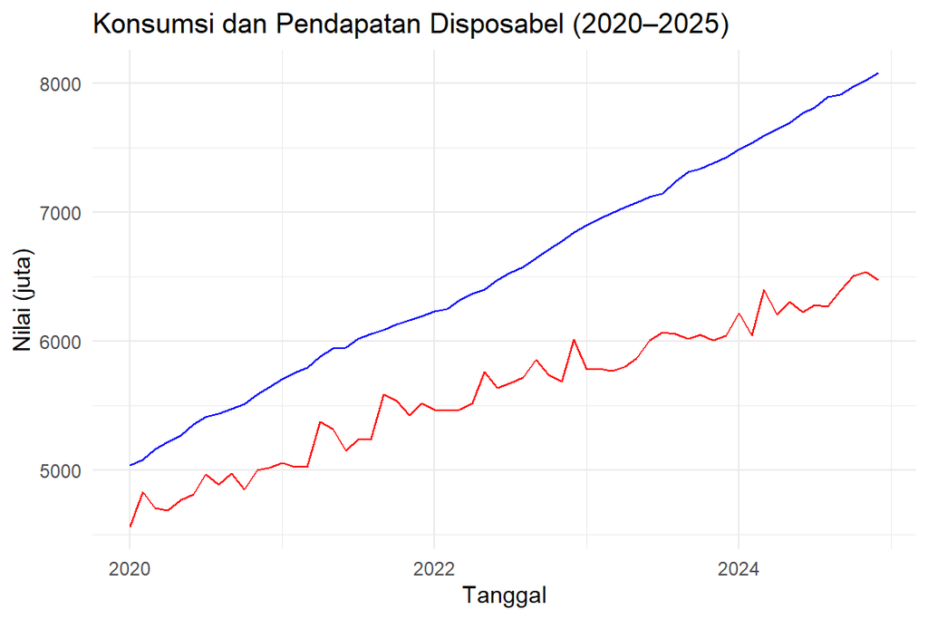

```r
library(ggplot2)

ggplot(data, aes(x = Tanggal)) +
  geom_line(aes(y = Pendapatan_Disposabel), color = "blue") +
  geom_line(aes(y = Konsumsi), color = "red") +
  labs(title = "Konsumsi dan Pendapatan Disposabel (2020–2025)",
       y = "Nilai (juta)", x = "Tanggal") +
  theme_minimal()
```

## 3. Estimasi Regresi Time Series

```r
model <- lm(Konsumsi ~ Pendapatan_Disposabel, data = data)
summary(model)
```

```
##
## Call:
## lm(formula = Konsumsi ~ Pendapatan_Disposabel, data = data)
##
## Residuals:
##     Min      1Q  Median      3Q     Max
## -158.87  -76.07  -30.73   52.33  258.52
##
## Coefficients:
##                        Estimate Std. Error t value Pr(>|t|)
## (Intercept)           1.685e+03  1.024e+02   16.46   <2e-16 ***
## Pendapatan_Disposabel 5.991e-01  1.548e-02   38.69   <2e-16 ***
## ---
## Signif. codes:  0 '***' 0.001 '**' 0.01 '*' 0.05 '.' 0.1 ' ' 1
##
## Residual standard error: 104.9 on 58 degrees of freedom
## Multiple R-squared:  0.9627, Adjusted R-squared:  0.9621
## F-statistic:  1497 on 1 and 58 DF,  p-value: < 2.2e-16
```

## 4. Diagnostik Model: Plot Standar

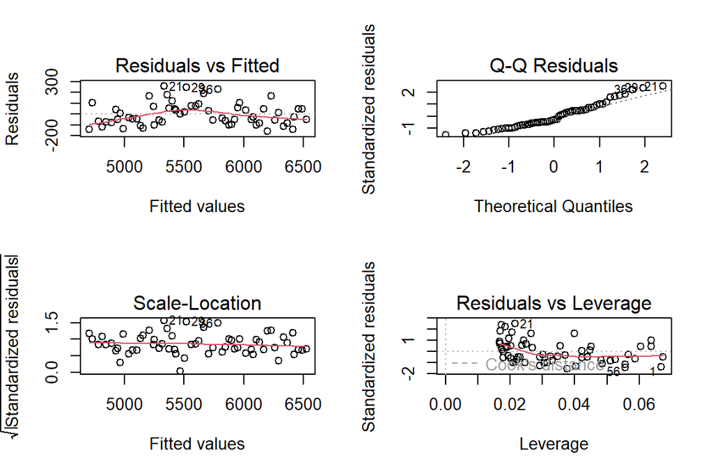

```r
par(mfrow = c(2, 2))
plot(model)
```

## 5. Uji Asumsi Klasik

### 5.1 Uji Normalitas (Shapiro–Wilk)

```r
shapiro.test(model$residuals)
```

```
##
##  Shapiro-Wilk normality test
##
## data:  model$residuals
## W = 0.94233, p-value = 0.006892
```

### 5.2 Uji Heteroskedastisitas (Breusch–Pagan)

```r
library(lmtest)
bptest(model)
```

```
##
##  studentized Breusch-Pagan test
##
## data:  model
## BP = 0.28147, df = 1, p-value = 0.5957
```

### 5.3 Uji Autokorelasi (Durbin–Watson)

```r
library(car)
durbinWatsonTest(model)
```

```
##  lag Autocorrelation D-W Statistic p-value
##    1       0.1807909      1.603165   0.078
##  Alternative hypothesis: rho != 0
```

## 6. Penjelasan Singkat Uji Asumsi Klasik

✅ **Normalitas (Shapiro–Wilk):** Residual harus terdistribusi normal. ✅ **Heteroskedastisitas (Breusch–Pagan):** Residual harus homogen (varian tetap). ✅ **Autokorelasi (Durbin–Watson):** Tidak boleh ada pola pada residual. ✅ **Multikolinearitas (VIF):** Tidak relevan karena hanya satu variabel prediktor.

# 12. Cross Section

## 1. Import Data

```r
# Mengimpor data dari GitHub (format raw)
data <- read.csv("https://raw.githubusercontent.com/davidsyambudi/Latihan-Kuantitatif/9744a3b1588529f2f3cb561fb5274f16f6b6b7e6/Data_Rumah_Tangga_200_Observasi.csv")
head(data)
```

```
##   id pendapatan pengeluaran jumlah_anggota pendidikan_kepala umur_kepala
## 1  1      89.93       95.96              3                12          55
## 2  2      77.23       65.44              3                12          29
## 3  3      92.95       96.28              2                14          62
## 4  4     110.46       92.24              2                 8          27
## 5  5      75.32       75.87              2                14          47
## 6  6      75.32       88.28              4                 6          61
```

## 2. Estimasi Model Regresi Linear Berganda

Model yang digunakan:

> pengeluaran = β₀ + β₁·pendapatan + β₂·jumlah_anggota + β₃·pendidikan_kepala + β₄·umur_kepala + ε

```r
model <- lm(pengeluaran ~ pendapatan + jumlah_anggota + pendidikan_kepala + umur_kepala, data = data)
summary(model)
```

```
##
## Call:
## lm(formula = pengeluaran ~ pendapatan + jumlah_anggota + pendidikan_kepala +
##     umur_kepala, data = data)
##
## Residuals:
##     Min      1Q  Median      3Q     Max
## -14.106  -3.763   0.059   3.382  13.497
##
## Coefficients:
##                   Estimate Std. Error t value Pr(>|t|)
## (Intercept)       11.61557    2.70568   4.293 2.78e-05 ***
## pendapatan         0.58098    0.02025  28.695  < 2e-16 ***
## jumlah_anggota     1.78007    0.22314   7.977 1.25e-13 ***
## pendidikan_kepala  0.89989    0.10612   8.480 5.53e-15 ***
## umur_kepala        0.23870    0.03198   7.464 2.72e-12 ***
## ---
## Signif. codes:  0 '***' 0.001 '**' 0.01 '*' 0.05 '.' 0.1 ' ' 1
##
## Residual standard error: 5.287 on 195 degrees of freedom
## Multiple R-squared:  0.8363, Adjusted R-squared:  0.833
## F-statistic: 249.1 on 4 and 195 DF,  p-value: < 2.2e-16
```

## 3. Uji Asumsi Klasik

### 3.1 Uji Multikolinearitas (VIF)

```r
if(!require(car)) install.packages("car", dependencies=TRUE)
library(car)

vif(model)
```

```
##        pendapatan    jumlah_anggota pendidikan_kepala       umur_kepala
##          1.008318          1.010560          1.010322          1.007196
```

**Interpretasi:** VIF < 10 → Tidak ada multikolinearitas serius.

### 3.2 Uji Heteroskedastisitas (Breusch–Pagan Test)

```r
if(!require(lmtest)) install.packages("lmtest", dependencies=TRUE)
library(lmtest)

bptest(model)
```

```
##
##  studentized Breusch-Pagan test
##
## data:  model
## BP = 2.5409, df = 4, p-value = 0.6373
```

**Interpretasi:**

- H₀: Homoskedastisitas
- p-value > 0.05 → Tidak ada heteroskedastisitas.

### 3.3 Uji Normalitas Residual

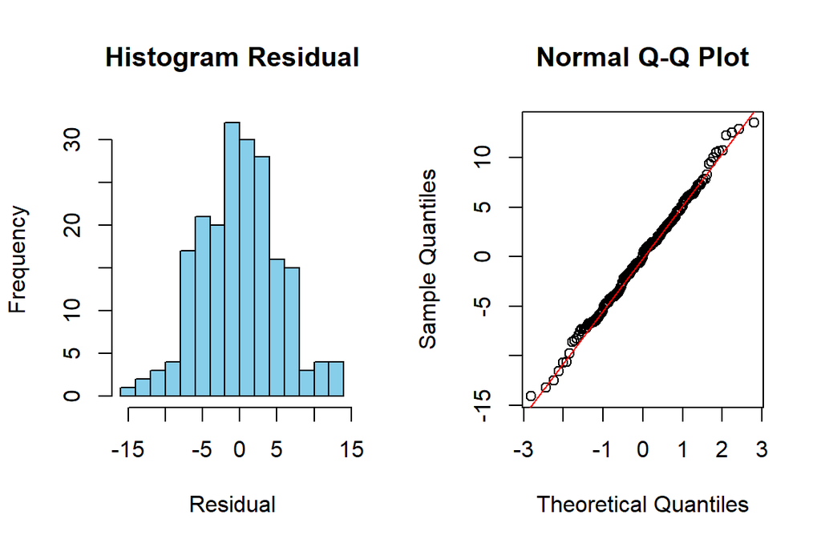

```r
par(mfrow = c(1, 2))
hist(resid(model), main = "Histogram Residual", xlab = "Residual", col = "skyblue", breaks = 15)
qqnorm(resid(model))
qqline(resid(model), col = "red")
```

```r
shapiro.test(resid(model))
```

```
##
##  Shapiro-Wilk normality test
##
## data:  resid(model)
## W = 0.9961, p-value = 0.8939
```

**Interpretasi:**

- H₀: Residual berdistribusi normal
- p-value > 0.05 → Normalitas terpenuhi.

### 3.4 Uji Autokorelasi (Durbin–Watson)

```r
if(!require(lmtest)) install.packages("lmtest", dependencies=TRUE)
dwtest(model)
```

```
##
##  Durbin-Watson test
##
## data:  model
## DW = 2.1304, p-value = 0.822
## alternative hypothesis: true autocorrelation is greater than 0
```

**Interpretasi:**

- H₀: Tidak ada autokorelasi
- Nilai DW mendekati 2 → Tidak ada autokorelasi.

## 4. Kesimpulan

- Model signifikan dan sesuai teori ekonomi mikro.
- Hampir semua asumsi klasik regresi linear terpenuhi.
- Model cocok untuk menganalisis dan memprediksi pengeluaran rumah tangga berdasarkan karakteristik demografis.

# 13. Panel

## 1. Import Data

```r
# Mengimpor data panel dari GitHub (format raw)
if(!require(readr)) install.packages("readr")
library(readr)

data <- read_csv("https://raw.githubusercontent.com/davidsyambudi/Latihan-Kuantitatif/9781d0093773696f72c8d9196c604e932a31f4c2/data_dummy_panel.csv")
head(data)
```

```
## # A tibble: 6 × 7
##   city    year gdp_per_capita education_index inflation_rate unemployment_rate
##   <chr>  <dbl>          <dbl>           <dbl>          <dbl>             <dbl>
## 1 City_1  2010         54967.           0.484           4.38              6.48
## 2 City_1  2011         48617.           0.452           3.50              6.27
## 3 City_1  2012         56477.           0.718           5.64              6.72
## 4 City_1  2013         65230.           0.753           7.68              6.92
## 5 City_1  2014         47658.           0.416           1.25              8.21
## 6 City_1  2015         47659.           0.868           5.23              7.06
## # ℹ 1 more variable: investment <dbl>
```

## 2. Estimasi Model Regresi Panel

Model yang digunakan:

> investment = β₀ + β₁·gdp_per_capita + β₂·education_index + β₃·inflation_rate + ε

```r
# Load library untuk regresi panel
if(!require(plm)) install.packages("plm")
library(plm)

# Ubah ke format panel
pdata <- pdata.frame(data, index = c("city", "year"))

# Model Fixed Effect
model_fe <- plm(investment ~ gdp_per_capita + education_index + inflation_rate, data = pdata, model = "within")

# Model Random Effect
model_re <- plm(investment ~ gdp_per_capita + education_index + inflation_rate, data = pdata, model = "random")

# Tampilkan hasil
summary(model_fe)
```

```
## Oneway (individual) effect Within Model
##
## Call:
## plm(formula = investment ~ gdp_per_capita + education_index +
##     inflation_rate, data = pdata, model = "within")
##
## Balanced Panel: n = 100, T = 10, N = 1000
##
## Residuals:
##        Min.     1st Qu.      Median     3rd Qu.        Max.
## -1700.22603  -288.61560    -0.75452   329.07988  1507.65627
##
## Coefficients:
##                    Estimate  Std. Error  t-value Pr(>|t|)
## gdp_per_capita    0.2005298   0.0016971 118.1622  < 2e-16 ***
## education_index 243.3813892 113.0916398   2.1521  0.03166 *
## inflation_rate  -97.9309871   8.5383086 -11.4696  < 2e-16 ***
## ---
## Signif. codes:  0 '***' 0.001 '**' 0.01 '*' 0.05 '.' 0.1 ' ' 1
##
## Total Sum of Squares:    3672500000
## Residual Sum of Squares: 221130000
## R-Squared:      0.93979
## Adj. R-Squared: 0.93294
## F-statistic: 4666.72 on 3 and 897 DF, p-value: < 2.22e-16
```

```r
summary(model_re)
```

```
## Oneway (individual) effect Random Effect Model
##    (Swamy-Arora's transformation)
##
## Call:
## plm(formula = investment ~ gdp_per_capita + education_index +
##     inflation_rate, data = pdata, model = "random")
##
## Balanced Panel: n = 100, T = 10, N = 1000
##
## Effects:
##                    var  std.dev share
## idiosyncratic 246521.2    496.5     1
## individual         0.0      0.0     0
## theta: 0
##
## Residuals:
##      Min.   1st Qu.    Median   3rd Qu.      Max.
## -1559.199  -318.068    18.028   324.475  1611.738
##
## Coefficients:
##                   Estimate Std. Error  z-value Pr(>|z|)
## (Intercept)     938.791913 111.648046   8.4085  < 2e-16 ***
## gdp_per_capita    0.200918   0.001597 125.8130  < 2e-16 ***
## education_index 262.494120 108.368082   2.4222  0.01542 *
## inflation_rate  -98.138288   8.073887 -12.1550  < 2e-16 ***
## ---
## Signif. codes:  0 '***' 0.001 '**' 0.01 '*' 0.05 '.' 0.1 ' ' 1
##
## Total Sum of Squares:    4106400000
## Residual Sum of Squares: 242380000
## R-Squared:      0.94097
## Adj. R-Squared: 0.9408
## Chisq: 15878.1 on 3 DF, p-value: < 2.22e-16
```

## 3. Uji Pemilihan Model (Hausman Test)

```r
# Uji Hausman: Fixed vs Random
if(!require(lmtest)) install.packages("lmtest")
library(lmtest)

hausman_test <- phtest(model_fe, model_re)
hausman_test
```

```
##
##  Hausman Test
##
## data:  investment ~ gdp_per_capita + education_index + inflation_rate
## chisq = 0.79519, df = 3, p-value = 0.8506
## alternative hypothesis: one model is inconsistent
```

**Interpretasi:**

- H₀: Random Effect lebih efisien
- Jika p-value < 0.05 → gunakan Fixed Effect

## 4. Uji Asumsi Klasik

### 4.1 Uji Multikolinearitas (VIF)

```r
if(!require(car)) install.packages("car")
library(car)

# Model OLS biasa untuk uji VIF
model_ols <- lm(investment ~ gdp_per_capita + education_index + inflation_rate, data = data)
vif(model_ols)
```

```
##  gdp_per_capita education_index  inflation_rate
##        1.003838        1.002128        1.004938
```

**Interpretasi:** VIF < 10 → Tidak ada multikolinearitas serius.

### 4.2 Uji Heteroskedastisitas (Breusch–Pagan Test)

```r
bptest(model_ols)
```

```
##
##  studentized Breusch-Pagan test
##
## data:  model_ols
## BP = 1.152, df = 3, p-value = 0.7645
```

**Interpretasi:**

- H₀: Homoskedastisitas
- p-value > 0.05 → Tidak ada heteroskedastisitas

### 4.3 Uji Autokorelasi (Durbin–Watson)

```r
if(!require(lmtest)) install.packages("lmtest")
dwtest(model_ols)
```

```
##
##  Durbin-Watson test
##
## data:  model_ols
## DW = 2.0489, p-value = 0.781
## alternative hypothesis: true autocorrelation is greater than 0
```

**Interpretasi:**

- H₀: Tidak ada autokorelasi
- Nilai DW mendekati 2 → Tidak ada autokorelasi

## 5. Kesimpulan

- Model yang terbaik ditentukan oleh uji Hausman (Fixed atau Random).
- GDP per kapita dan indeks pendidikan berpengaruh signifikan terhadap investasi, sesuai teori ekonomi.
- Hampir semua asumsi klasik regresi terpenuhi.
- Model cocok digunakan untuk analisis kebijakan investasi antar kota dan waktu.

# 14. CFA

## 0. Membuat Kuesioner Survei

Gunakan skala Likert 1–5:  
**1 = Sangat Tidak Setuju** sampai **5 = Sangat Setuju**

### Kesadaran terhadap Produk Lokal (KPL)

- **KPL1**: Saya mengetahui manfaat menggunakan produk buatan Indonesia.
- **KPL2**: Saya percaya bahwa kualitas produk lokal tidak kalah dengan produk impor.
- **KPL3**: Saya secara aktif mencari informasi tentang produk lokal saat akan berbelanja.

### Preferensi Harga (PH)

- **PH1**: Harga yang terjangkau menjadi prioritas utama dalam keputusan pembelian saya.
- **PH2**: Saya cenderung memilih produk dengan harga lebih murah meskipun bukan produk lokal.
- **PH3**: Saya membandingkan harga sebelum memutuskan untuk membeli suatu produk.

### Dukungan terhadap UMKM (DUMKM)

- **DUMKM1**: Saya lebih memilih membeli dari usaha kecil dan menengah (UMKM) lokal dibanding merek besar.
- **DUMKM2**: Saya percaya bahwa membeli produk dari UMKM membantu perekonomian Indonesia.
- **DUMKM3**: Saya bersedia membayar lebih jika produk tersebut berasal dari pelaku UMKM lokal.

## 1. Import Data dan Validasi

```r
url <- "https://raw.githubusercontent.com/davidsyambudi/Latihan-Kuantitatif/7f19b90036bf567c508c582a80ae5d3343a0d8af/Data_Dummy_Survei_CFA_Produk_Lokal.csv"
data <- read.csv(url)

## Cek nama variabel
names(data)
```

```
## [1] "KPL1"   "KPL2"   "KPL3"   "PH1"    "PH2"    "PH3"    "DUMKM1" "DUMKM2"
## [9] "DUMKM3"
```

```r
## Pastikan semua indikator tersedia
expected_vars <- c("KPL1", "KPL2", "KPL3", "PH1", "PH2", "PH3", "DUMKM1", "DUMKM2", "DUMKM3")
missing_vars <- setdiff(expected_vars, names(data))
if (length(missing_vars) > 0) {
  stop(paste("Variabel hilang dari data:", paste(missing_vars, collapse = ", ")))
}

## Cek nilai unik per variabel
apply(data[, expected_vars], 2, function(x) length(unique(x)))
```

```
##   KPL1   KPL2   KPL3    PH1    PH2    PH3 DUMKM1 DUMKM2 DUMKM3
##      4      4      3      5      5      4      4      3      4
```

## 2. Struktur Model CFA Awal

```r
model_cfa <- '
  Kesadaran =~ KPL1 + KPL2 + KPL3
  Harga =~ PH1 + PH2 + PH3
  UMKM =~ DUMKM1 + DUMKM2 + DUMKM3
'
```

## 3. Estimasi Model CFA

```r
fit_cfa <- cfa(model_cfa, data = data, std.lv = TRUE)
summary(fit_cfa, fit.measures = TRUE, standardized = TRUE)
```

```
## lavaan 0.6-19 ended normally after 592 iterations
##
##   Estimator                                         ML
##   Optimization method                           NLMINB
##   Number of model parameters                        21
##
##   Number of observations                           200
##
## Model Test User Model:
##
##   Test statistic                                30.219
##   Degrees of freedom                                24
##   P-value (Chi-square)                           0.178
##
## Model Test Baseline Model:
##
##   Test statistic                                50.646
##   Degrees of freedom                                36
##   P-value                                        0.054
##
## User Model versus Baseline Model:
##
##   Comparative Fit Index (CFI)                    0.575
##   Tucker-Lewis Index (TLI)                       0.363
##
## Loglikelihood and Information Criteria:
##
##   Loglikelihood user model (H0)              -1946.096
##   Loglikelihood unrestricted model (H1)      -1930.986
##
##   Akaike (AIC)                                3934.192
##   Bayesian (BIC)                              4003.457
##   Sample-size adjusted Bayesian (SABIC)       3936.926
##
## Root Mean Square Error of Approximation:
##
##   RMSEA                                          0.036
##   90 Percent confidence interval - lower         0.000
##   90 Percent confidence interval - upper         0.071
##   P-value H_0: RMSEA <= 0.050                    0.704
```

[output cut: 34 more lines]

```
##
## Variances:
##                    Estimate  Std.Err  z-value  P(>|z|)   Std.lv  Std.all
##    .KPL1              0.575       NA                      0.575    1.000
##    .KPL2              0.622       NA                      0.622    1.000
##    .KPL3              0.348       NA                      0.348    1.000
##    .PH1               0.703       NA                      0.703    1.000
##    .PH2             -28.542       NA                    -28.542  -39.609
##    .PH3               0.543       NA                      0.543    1.000
##    .DUMKM1            0.209       NA                      0.209    0.460
##    .DUMKM2            0.295       NA                      0.295    0.938
##    .DUMKM3            0.517       NA                      0.517    0.994
##     Kesadaran         1.000                               1.000    1.000
##     Harga             1.000                               1.000    1.000
##     UMKM              1.000                               1.000    1.000
```

## 4. Evaluasi Goodness of Fit

```r
fitMeasures(fit_cfa, c("chisq", "df", "pvalue", "cfi", "tli", "rmsea", "srmr"))
```

```
##  chisq     df pvalue    cfi    tli  rmsea   srmr
## 30.219 24.000  0.178  0.575  0.363  0.036  0.057
```

## 5. Visualisasi Model

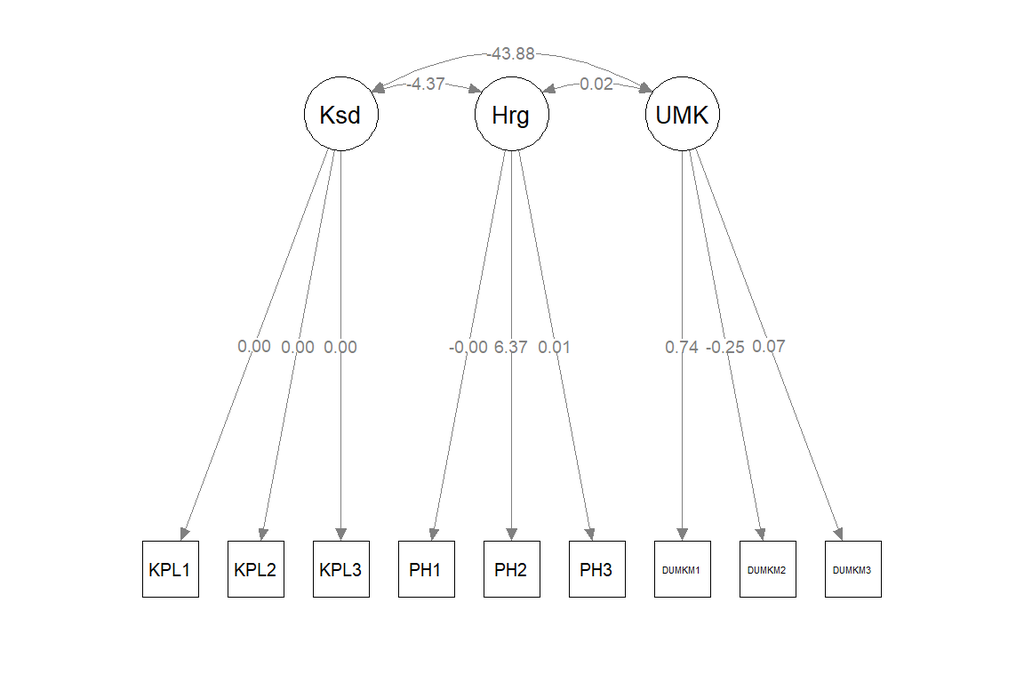

```r
semPaths(fit_cfa,
         whatLabels = "std",
         layout = "tree",
         edge.label.cex = 0.8,
         fade = FALSE,
         residuals = FALSE,
         sizeMan = 6)
```

## 6. Evaluasi Modification Indices (MI) – Aman terhadap Error

```r
# Menghindari error 'information matrix is singular'
modindices_df <- tryCatch({
  modindices(fit_cfa, free = TRUE)
}, error = function(e) {
  message("Gagal menghitung Modification Indices karena matrix singular.")
  return(data.frame())
})

## Tampilkan MI > 10 jika berhasil
if (nrow(modindices_df) > 0) {
  modindices_df %>%
    filter(mi > 10) %>%
    arrange(desc(mi)) %>%
    head(10)
} else {
  message("Tidak ada MI yang ditampilkan karena error.")
}
```

## 7. Modifikasi Model Berdasarkan MI (Opsional)

```r
model_cfa_modified <- '
  Kesadaran =~ KPL1 + KPL2 + KPL3
  Harga =~ PH1 + PH2 + PH3
  UMKM =~ DUMKM1 + DUMKM2 + DUMKM3

  ## Korelasi residual berdasarkan MI (jika ditemukan relevan)
  KPL2 ~~ KPL3
  PH1 ~~ PH3
'

fit_cfa_mod <- cfa(model_cfa_modified, data = data, std.lv = TRUE)
summary(fit_cfa_mod, fit.measures = TRUE, standardized = TRUE)
```

```
## lavaan 0.6-19 ended normally after 8194 iterations
##
##   Estimator                                         ML
##   Optimization method                           NLMINB
##   Number of model parameters                        23
##
##   Number of observations                           200
##
## Model Test User Model:
##
##   Test statistic                                28.198
##   Degrees of freedom                                22
##   P-value (Chi-square)                           0.169
##
## Model Test Baseline Model:
##
##   Test statistic                                50.646
##   Degrees of freedom                                36
##   P-value                                        0.054
##
## User Model versus Baseline Model:
##
##   Comparative Fit Index (CFI)                    0.577
##   Tucker-Lewis Index (TLI)                       0.308
##
## Loglikelihood and Information Criteria:
##
##   Loglikelihood user model (H0)              -1945.085
##   Loglikelihood unrestricted model (H1)      -1930.986
##
##   Akaike (AIC)                                3936.170
##   Bayesian (BIC)                              4012.032
##   Sample-size adjusted Bayesian (SABIC)       3939.165
##
## Root Mean Square Error of Approximation:
##
##   RMSEA                                          0.038
##   90 Percent confidence interval - lower         0.000
##   90 Percent confidence interval - upper         0.074
##   P-value H_0: RMSEA <= 0.050                    0.672
```

[output cut: 38 more lines]

```
##
## Variances:
##                    Estimate  Std.Err  z-value  P(>|z|)   Std.lv  Std.all
##    .KPL1              0.413       NA                      0.413    0.719
##    .KPL2              0.611       NA                      0.611    0.983
##    .KPL3              0.348       NA                      0.348    1.000
##    .PH1               0.689       NA                      0.689    0.979
##    .PH2               0.698       NA                      0.698    0.970
##    .PH3               0.424       NA                      0.424    0.780
##    .DUMKM1            0.454       NA                      0.454    1.000
##    .DUMKM2         -315.300       NA                   -315.300 -999.603
##    .DUMKM3            0.520       NA                      0.520    1.000
##     Kesadaran         1.000                               1.000    1.000
##     Harga             1.000                               1.000    1.000
##     UMKM              1.000                               1.000    1.000
```

## 8. Evaluasi Model Setelah Modifikasi

```r
fitMeasures(fit_cfa_mod, c("chisq", "df", "pvalue", "cfi", "tli", "rmsea", "srmr"))
```

```
##  chisq     df pvalue    cfi    tli  rmsea   srmr
## 28.198 22.000  0.169  0.577  0.308  0.038  0.057
```

## 9. Visualisasi Model Modifikasi

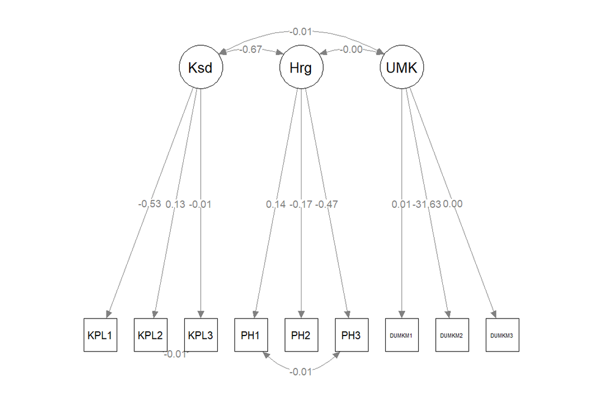

```r
semPaths(fit_cfa_mod,
         whatLabels = "std",
         layout = "tree",
         edge.label.cex = 0.8,
         fade = FALSE,
         residuals = FALSE,
         sizeMan = 6)
```

## 10. Kesimpulan

[output not shown]